# Wine Quality Prediction

## Problem Statement

### Context

Wine is a beverage made from fermented grapes and other fruit juices with a low amount of alcohol content. Wine is the second most popular alcoholic drink in the world after beer, and it is one of the most highly consumed beverages.

Generally, the quality of wine is graded based on the taste of the wine and vintage but this process is time-consuming, costly, and not efficient as the quality of the wine also depends on other physiochemical attributes like fixed acidity, volatile acidity, etc. Also, it is not always possible to ensure wine quality by experts when there is a huge demand for the product as it will increase the cost significantly.

### Objective:

Moonshine is a red wine company that produces premium high-quality wines. The company wants to improve its production efficiency and reduce the cost and additional time involved in wine tasting. You as a data scientist at Moonshine company have to build a predictive model that can help to identify the premium quality wines using the available data.

### Data Description:

- fixed acidity: Fixed Acidity impart sourness and resist microbial infection, measured in no. of grams of tartaric acid per dm3
- volatile acidity: No. of grams of acetic acid per dm3 of wine. Too high levels can lead to an unpleasant, vinegar-like taste
- citric acid: No. of grams of citric acid per dm3 of wine. Citric acid can add freshness and flavor to wines
- residual sugar: Remaining sugar after fermentation stops, measured in no. of grams per dm3.
- chlorides: No. of grams of sodium chloride i.e. salt per dm3 of wine
- free sulfur dioxide: No. of grams of free sulfite per dm3 of wine
- total sulfur dioxide: No. of grams of total sulfite (free sulphite+ bound) per dm3 of wine
- density: Density in gram per cm3
- pH: Describes how acidic or basic a wine is on a scale from 0 (very acidic) to 14 (very basic). The pH of the wine can help measure the ripeness of the wine
- sulphates: No. of grams of potassium sulfate per dm3 of wine
- alcohol: Volume of alcohol in percentage
- quality: Wine quality score between 3 to 8

## Importing Libraries

```python
# Suppressing warnings
import warnings
warnings.filterwarnings('ignore')

# Data management libraries
import numpy as np
import pandas as pd

# Visualization libraries
import matplotlib.pyplot as plt
import seaborn as sns
%matplotlib inline

# Classification libraries
from sklearn.linear_model import LogisticRegression
from sklearn import tree
from sklearn.tree import DecisionTreeClassifier
from sklearn. ensemble import (BaggingClassifier, RandomForestClassifier,
                               AdaBoostClassifier, GradientBoostingClassifier,
                               StackingClassifier)
from xgboost import XGBClassifier
from sklearn.model_selection import GridSearchCV, train_test_split
from sklearn.metrics import (accuracy_score, recall_score, precision_score,
                             f1_score, confusion_matrix, make_scorer)

# Setting the theme and fontsize of figures
sns.set_theme(style = 'darkgrid', font_scale = 1.13)

# Restricting the float value of a dataframe to 3 decimal points
pd.set_option('display.float_format', lambda x: '%.3f' % x)
# Removing the limit for the number of displayed columns
pd.set_option("display.max_columns", None)

# Mounting the drive
from google.colab import drive
drive.mount('/content/drive/')
```

## Loading the Dataset

```python
# Importing dataset
data_orig = pd.read_csv('/content/drive/MyDrive/Python_files/winequality_red.csv', sep=';')
# Ensuring the original data remains untouched
df = data_orig.copy()
```

## Overview of the Dataset

### Peeking the First and Last Few Rows

```python
df.head(7)
```

|  | fixed acidity | volatile acidity | citric acid | residual sugar | chlorides | free sulfur dioxide | total sulfur dioxide | density | pH | sulphates | alcohol | quality |
| --- | --- | --- | --- | --- | --- | --- | --- | --- | --- | --- | --- | --- |
| 0 | 7.400 | 0.700 | 0.000 | 1.900 | 0.076 | 11.000 | 34.000 | 0.998 | 3.510 | 0.560 | 9.400 | 5 |
| 1 | 7.800 | 0.880 | 0.000 | 2.600 | 0.098 | 25.000 | 67.000 | 0.997 | 3.200 | 0.680 | 9.800 | 5 |
| 2 | 7.800 | 0.760 | 0.040 | 2.300 | 0.092 | 15.000 | 54.000 | 0.997 | 3.260 | 0.650 | 9.800 | 5 |
| 3 | 11.200 | 0.280 | 0.560 | 1.900 | 0.075 | 17.000 | 60.000 | 0.998 | 3.160 | 0.580 | 9.800 | 6 |
| 4 | 7.400 | 0.700 | 0.000 | 1.900 | 0.076 | 11.000 | 34.000 | 0.998 | 3.510 | 0.560 | 9.400 | 5 |
| 5 | 7.400 | 0.660 | 0.000 | 1.800 | 0.075 | 13.000 | 40.000 | 0.998 | 3.510 | 0.560 | 9.400 | 5 |
| 6 | 7.900 | 0.600 | 0.060 | 1.600 | 0.069 | 15.000 | 59.000 | 0.996 | 3.300 | 0.460 | 9.400 | 5 |

```python
df.tail(7)
```

|  | fixed acidity | volatile acidity | citric acid | residual sugar | chlorides | free sulfur dioxide | total sulfur dioxide | density | pH | sulphates | alcohol | quality |
| --- | --- | --- | --- | --- | --- | --- | --- | --- | --- | --- | --- | --- |
| 1592 | 6.300 | 0.510 | 0.130 | 2.300 | 0.076 | 29.000 | 40.000 | 0.996 | 3.420 | 0.750 | 11.000 | 6 |
| 1593 | 6.800 | 0.620 | 0.080 | 1.900 | 0.068 | 28.000 | 38.000 | 0.997 | 3.420 | 0.820 | 9.500 | 6 |
| 1594 | 6.200 | 0.600 | 0.080 | 2.000 | 0.090 | 32.000 | 44.000 | 0.995 | 3.450 | 0.580 | 10.500 | 5 |
| 1595 | 5.900 | 0.550 | 0.100 | 2.200 | 0.062 | 39.000 | 51.000 | 0.995 | 3.520 | 0.760 | 11.200 | 6 |
| 1596 | 6.300 | 0.510 | 0.130 | 2.300 | 0.076 | 29.000 | 40.000 | 0.996 | 3.420 | 0.750 | 11.000 | 6 |
| 1597 | 5.900 | 0.645 | 0.120 | 2.000 | 0.075 | 32.000 | 44.000 | 0.995 | 3.570 | 0.710 | 10.200 | 5 |
| 1598 | 6.000 | 0.310 | 0.470 | 3.600 | 0.067 | 18.000 | 42.000 | 0.995 | 3.390 | 0.660 | 11.000 | 6 |

### Shape of Dataset

```python
print('Dataset has {} rows and {} columns.'.format(df.shape[0], df.shape[1]))
```

```
Dataset has 1599 rows and 12 columns.
```

### General Information on Features

```python
df.info()
```

```
<class 'pandas.core.frame.DataFrame'>
RangeIndex: 1599 entries, 0 to 1598
Data columns (total 12 columns):
 #   Column                Non-Null Count  Dtype
---  ------                --------------  -----
 0   fixed acidity         1599 non-null   float64
 1   volatile acidity      1599 non-null   float64
 2   citric acid           1599 non-null   float64
 3   residual sugar        1599 non-null   float64
 4   chlorides             1599 non-null   float64
 5   free sulfur dioxide   1599 non-null   float64
 6   total sulfur dioxide  1599 non-null   float64
 7   density               1599 non-null   float64
 8   pH                    1599 non-null   float64
 9   sulphates             1599 non-null   float64
 10  alcohol               1599 non-null   float64
 11  quality               1599 non-null   int64
dtypes: float64(11), int64(1)
memory usage: 150.0 KB
```

### Missing Values and Duplicates

```python
print('Dataset has {} duplicates and {} missing values.'.format(df.duplicated().sum(),
                                                                df.isnull().sum().sum()))
```

```
Dataset has 240 duplicates and 0 missing values.
```

```python
# Dropping all duplicated columns
df.drop_duplicates(inplace = True)
print('No. of duplicates in the updated dataset:', df.duplicated().sum())
```

```
No. of duplicates in the updated dataset: 0
```

```python
df.shape
```

```
(1359, 12)
```

### Statistical Summary

```python
df.describe().T
```

|  | count | mean | std | min | 25% | 50% | 75% | max |
| --- | --- | --- | --- | --- | --- | --- | --- | --- |
| fixed acidity | 1359.000 | 8.311 | 1.737 | 4.600 | 7.100 | 7.900 | 9.200 | 15.900 |
| volatile acidity | 1359.000 | 0.529 | 0.183 | 0.120 | 0.390 | 0.520 | 0.640 | 1.580 |
| citric acid | 1359.000 | 0.272 | 0.196 | 0.000 | 0.090 | 0.260 | 0.430 | 1.000 |
| residual sugar | 1359.000 | 2.523 | 1.352 | 0.900 | 1.900 | 2.200 | 2.600 | 15.500 |
| chlorides | 1359.000 | 0.088 | 0.049 | 0.012 | 0.070 | 0.079 | 0.091 | 0.611 |
| free sulfur dioxide | 1359.000 | 15.893 | 10.447 | 1.000 | 7.000 | 14.000 | 21.000 | 72.000 |
| total sulfur dioxide | 1359.000 | 46.826 | 33.409 | 6.000 | 22.000 | 38.000 | 63.000 | 289.000 |
| density | 1359.000 | 0.997 | 0.002 | 0.990 | 0.996 | 0.997 | 0.998 | 1.004 |
| pH | 1359.000 | 3.310 | 0.155 | 2.740 | 3.210 | 3.310 | 3.400 | 4.010 |
| sulphates | 1359.000 | 0.659 | 0.171 | 0.330 | 0.550 | 0.620 | 0.730 | 2.000 |
| alcohol | 1359.000 | 10.432 | 1.082 | 8.400 | 9.500 | 10.200 | 11.100 | 14.900 |
| quality | 1359.000 | 5.623 | 0.824 | 3.000 | 5.000 | 6.000 | 6.000 | 8.000 |

```python
# We take any wine with a quality about 75th percentile as premium
premimum_qualifier = lambda x: 'Premium' if x > 6 else 'Non-Premium'

df['quality_cat'] = df['quality'].apply(premimum_qualifier)
```

```python
# Converting object cols into categorical cols
cat_cols = df.select_dtypes(include = ['object', 'int']).columns.tolist()
for col in cat_cols:
    df[col] = pd.Categorical(df[col])
df.info()
```

```
<class 'pandas.core.frame.DataFrame'>
Int64Index: 1359 entries, 0 to 1598
Data columns (total 13 columns):
 #   Column                Non-Null Count  Dtype
---  ------                --------------  -----
 0   fixed acidity         1359 non-null   float64
 1   volatile acidity      1359 non-null   float64
 2   citric acid           1359 non-null   float64
 3   residual sugar        1359 non-null   float64
 4   chlorides             1359 non-null   float64
 5   free sulfur dioxide   1359 non-null   float64
 6   total sulfur dioxide  1359 non-null   float64
 7   density               1359 non-null   float64
 8   pH                    1359 non-null   float64
 9   sulphates             1359 non-null   float64
 10  alcohol               1359 non-null   float64
 11  quality               1359 non-null   category
 12  quality_cat           1359 non-null   category
dtypes: category(2), float64(11)
memory usage: 130.4 KB
```

## Exploratory Data Analysis

### Univariate Analysis

```python
# Auxiliary function for annotating the bars in a countplot
def countplot_labeling(cntplt, data, perc = True, decimal = 1):
  ''' This function gets a countplot and the dataset that has generated
  the plot to produce the values corresponding to each bar (category).
  If perc = True, percentages will be shown.'''

  from math import isnan

  total = data.shape[0]  # total number of values in the dataset
  for p in cntplt.patches:
        height_val = float(p.get_height())
        if(isnan(height_val)):
          height_val = 0
        if(abs(height_val - round(height_val)) < 1e-6):
          height_val = int(height_val)
        if perc == True:
          # percentage of each category
          label = "{:.1f}%".format(100*height_val/total)
        else:
          label = "{}".format(round(height_val,decimal))  # count of each category
        x = p.get_x() + p.get_width()/2  # width of the plot
        y = p.get_height()  # height of the plot

        if(height_val == 0):
          label = '0'

        # annotate the bar
        cntplt.annotate(label, (x, y), ha = "center", va = "center", size = 12, xytext = (0, 5), textcoords = "offset points")
```

**`Fixed Acidicity`**

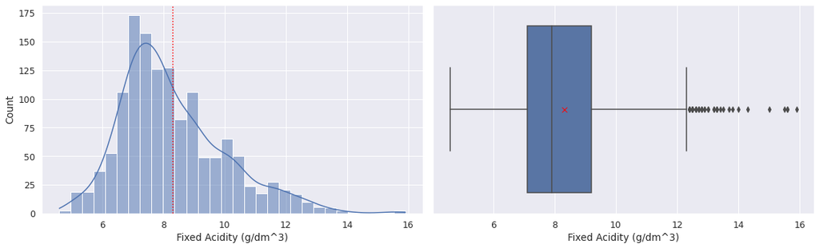

```python
plt.figure(figsize = (16, 5));
plt.subplot(121);
sns.histplot(data = df, x = 'fixed acidity', kde = True)
plt.axvline(df['fixed acidity'].mean(), linestyle = ':', color = 'red');
plt.xlabel('Fixed Acidity (g/dm^3)');
plt.subplot(122);
sns.boxplot(data = df, x = 'fixed acidity', showmeans = True,
            meanprops = {'marker': 'x', 'markerfacecolor': 'red', 'markeredgecolor': 'red', 'markersize': '7'});
plt.xlabel('Fixed Acidity (g/dm^3)');
plt.tight_layout();
```

**`Volatile Acidicity`**

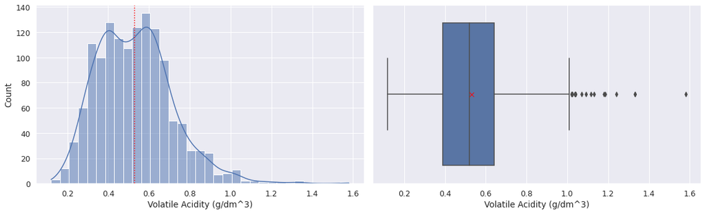

```python
plt.figure(figsize = (16, 5));
plt.subplot(121);
sns.histplot(data = df, x = 'volatile acidity', kde = True)
plt.axvline(df['volatile acidity'].mean(), linestyle = ':', color = 'red');
plt.xlabel('Volatile Acidity (g/dm^3)');
plt.subplot(122);
sns.boxplot(data = df, x = 'volatile acidity', showmeans = True,
            meanprops = {'marker': 'x', 'markerfacecolor': 'red', 'markeredgecolor': 'red', 'markersize': '7'});
plt.xlabel('Volatile Acidity (g/dm^3)');
plt.tight_layout();
```

**`Citric Acid`**

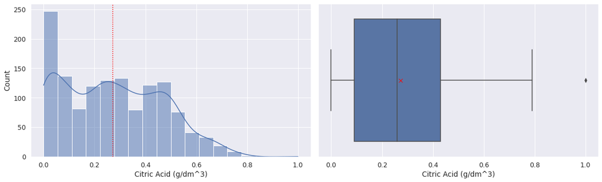

```python
plt.figure(figsize = (16, 5));
plt.subplot(121);
sns.histplot(data = df, x = 'citric acid', kde = True, bins = 18)
plt.axvline(df['citric acid'].mean(), linestyle = ':', color = 'red');
plt.xlabel('Citric Acid (g/dm^3)');
plt.subplot(122);
sns.boxplot(data = df, x = 'citric acid', showmeans = True,
            meanprops = {'marker': 'x', 'markerfacecolor': 'red', 'markeredgecolor': 'red', 'markersize': '7'});
plt.xlabel('Citric Acid (g/dm^3)');
plt.tight_layout();
```

**`Residual Sugar`**

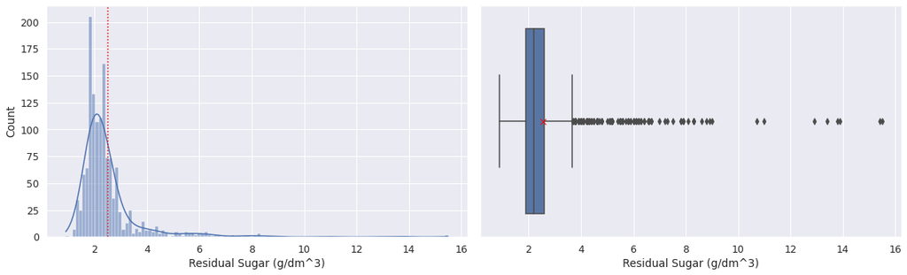

```python
plt.figure(figsize = (16, 5));
plt.subplot(121);
sns.histplot(data = df, x = 'residual sugar', kde = True)
plt.axvline(df['residual sugar'].mean(), linestyle = ':', color = 'red');
plt.xlabel('Residual Sugar (g/dm^3)');
plt.subplot(122);
sns.boxplot(data = df, x = 'residual sugar', showmeans = True,
            meanprops = {'marker': 'x', 'markerfacecolor': 'red', 'markeredgecolor': 'red', 'markersize': '7'});
plt.xlabel('Residual Sugar (g/dm^3)');
plt.tight_layout();
```

**`Chlorides`**

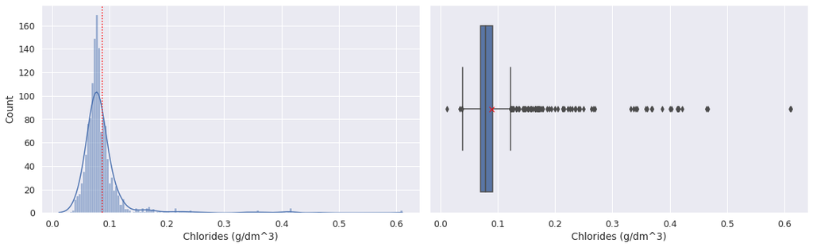

```python
plt.figure(figsize = (16, 5));
plt.subplot(121);
sns.histplot(data = df, x = 'chlorides', kde = True)
plt.axvline(df['chlorides'].mean(), linestyle = ':', color = 'red');
plt.xlabel('Chlorides (g/dm^3)');
plt.subplot(122);
sns.boxplot(data = df, x = 'chlorides', showmeans = True,
            meanprops = {'marker': 'x', 'markerfacecolor': 'red', 'markeredgecolor': 'red', 'markersize': '7'});
plt.xlabel('Chlorides (g/dm^3)');
plt.tight_layout();
```

**`Free Sulfur Dioxide`**

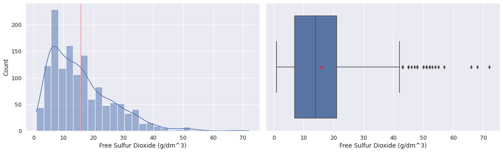

```python
plt.figure(figsize = (16, 5));
plt.subplot(121);
sns.histplot(data = df, x = 'free sulfur dioxide', kde = True)
plt.axvline(df['free sulfur dioxide'].mean(), linestyle = ':', color = 'red');
plt.xlabel('Free Sulfur Dioxide (g/dm^3)');
plt.subplot(122);
sns.boxplot(data = df, x = 'free sulfur dioxide', showmeans = True,
            meanprops = {'marker': 'x', 'markerfacecolor': 'red', 'markeredgecolor': 'red', 'markersize': '7'});
plt.xlabel('Free Sulfur Dioxide (g/dm^3)');
plt.tight_layout();
```

**`Total Sulfur Dioxide`**

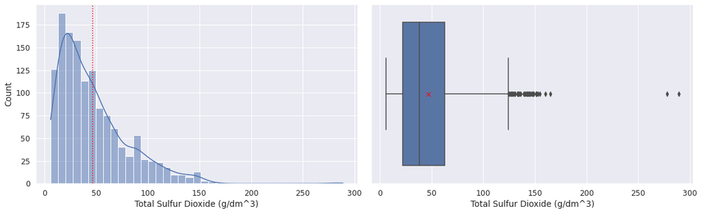

```python
plt.figure(figsize = (16, 5));
plt.subplot(121);
sns.histplot(data = df, x = 'total sulfur dioxide', kde = True)
plt.axvline(df['total sulfur dioxide'].mean(), linestyle = ':', color = 'red');
plt.xlabel('Total Sulfur Dioxide (g/dm^3)');
plt.subplot(122);
sns.boxplot(data = df, x = 'total sulfur dioxide', showmeans = True,
            meanprops = {'marker': 'x', 'markerfacecolor': 'red', 'markeredgecolor': 'red', 'markersize': '7'});
plt.xlabel('Total Sulfur Dioxide (g/dm^3)');
plt.tight_layout();
```

**`Density`**

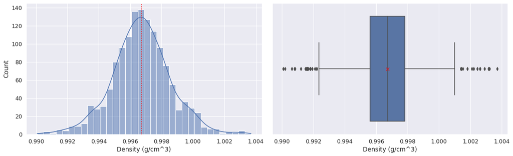

```python
plt.figure(figsize = (16, 5));
plt.subplot(121);
sns.histplot(data = df, x = 'density', kde = True)
plt.axvline(df['density'].mean(), linestyle = ':', color = 'red');
plt.xlabel('Density (g/cm^3)');
plt.subplot(122);
sns.boxplot(data = df, x = 'density', showmeans = True,
            meanprops = {'marker': 'x', 'markerfacecolor': 'red', 'markeredgecolor': 'red', 'markersize': '7'});
plt.xlabel('Density (g/cm^3)');
plt.tight_layout();
```

**`pH`**

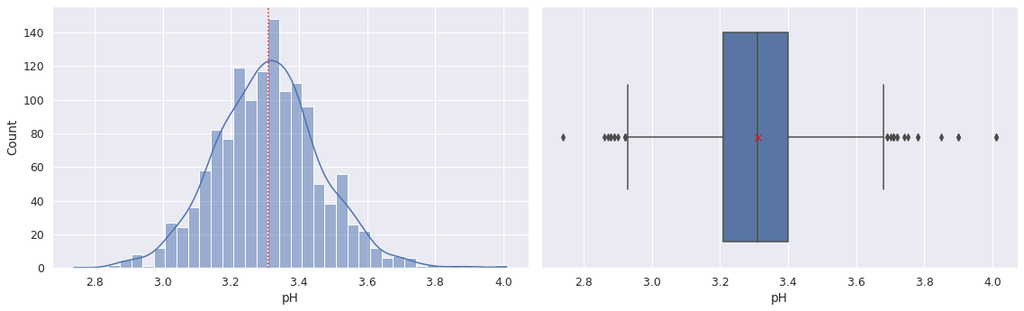

```python
plt.figure(figsize = (16, 5));
plt.subplot(121);
sns.histplot(data = df, x = 'pH', kde = True)
plt.axvline(df['pH'].mean(), linestyle = ':', color = 'red');
plt.xlabel('pH');
plt.subplot(122);
sns.boxplot(data = df, x = 'pH', showmeans = True,
            meanprops = {'marker': 'x', 'markerfacecolor': 'red', 'markeredgecolor': 'red', 'markersize': '7'});
plt.xlabel('pH');
plt.tight_layout();
```

**`Sulphates`**

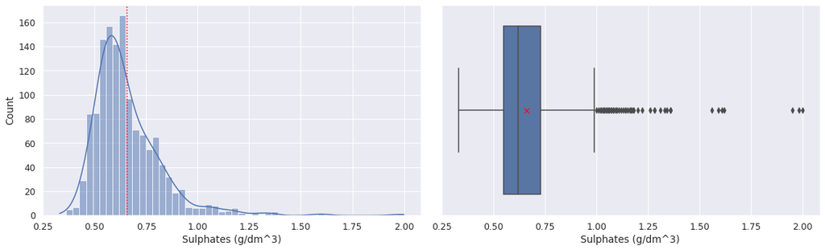

```python
plt.figure(figsize = (16, 5));
plt.subplot(121);
sns.histplot(data = df, x = 'sulphates', kde = True)
plt.axvline(df['sulphates'].mean(), linestyle = ':', color = 'red');
plt.xlabel('Sulphates (g/dm^3)');
plt.subplot(122);
sns.boxplot(data = df, x = 'sulphates', showmeans = True,
            meanprops = {'marker': 'x', 'markerfacecolor': 'red', 'markeredgecolor': 'red', 'markersize': '7'});
plt.xlabel('Sulphates (g/dm^3)');
plt.tight_layout();
```

**`Alcohol`**

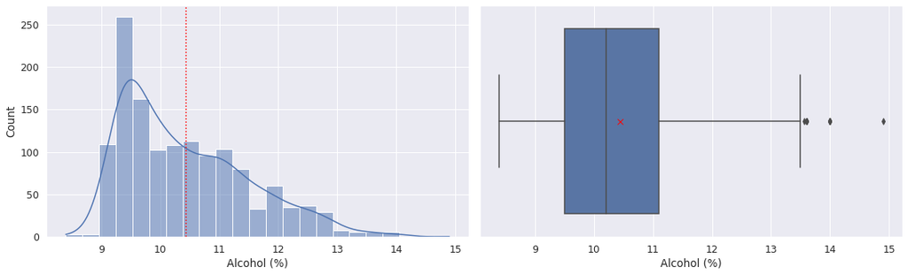

```python
plt.figure(figsize = (16, 5));
plt.subplot(121);
sns.histplot(data = df, x = 'alcohol', kde = True)
plt.axvline(df['alcohol'].mean(), linestyle = ':', color = 'red');
plt.xlabel('Alcohol (%)');
plt.subplot(122);
sns.boxplot(data = df, x = 'alcohol', showmeans = True,
            meanprops = {'marker': 'x', 'markerfacecolor': 'red', 'markeredgecolor': 'red', 'markersize': '7'});
plt.xlabel('Alcohol (%)');
plt.tight_layout();
```

**`Quality`**

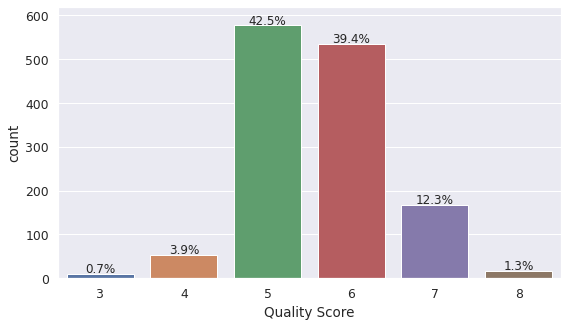

```python
# Quality rating
plt.figure(figsize = (9, 5));
cntplt = sns.countplot(data = df, x = 'quality');
countplot_labeling(cntplt, df);
plt.xlabel('Quality Score');
plt.ylim(0, 620);
```

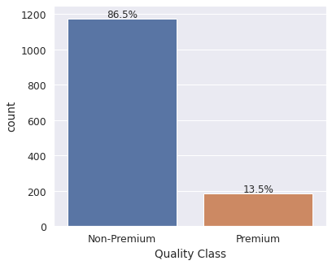

```python
# Premium or not
plt.figure(figsize = (6, 5));
cntplt = sns.countplot(data = df, x = 'quality_cat');
countplot_labeling(cntplt, df);
plt.xlabel('Quality Class');
plt.ylim(0, 1250);
```

### Bivariate Analysis

**`Correlation Heatmap`**

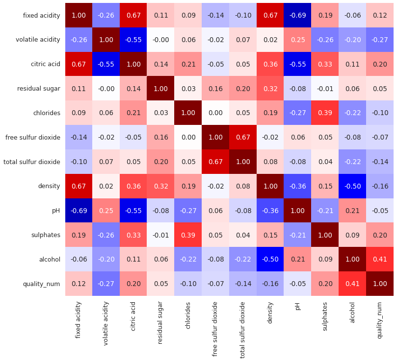

```python
# Assigning 0/1 to quality classes
df['quality_num'] = df['quality_cat'].replace(['Non-Premium', 'Premium'], [0, 1])

plt.figure(figsize = (12, 11));
sns.heatmap(data = df.corr(), annot = True, fmt = '.2f', vmin = -1, vmax = 1,
            cmap = 'seismic', cbar = False);
```

**`Quality vs. Fixed Acidicity`**

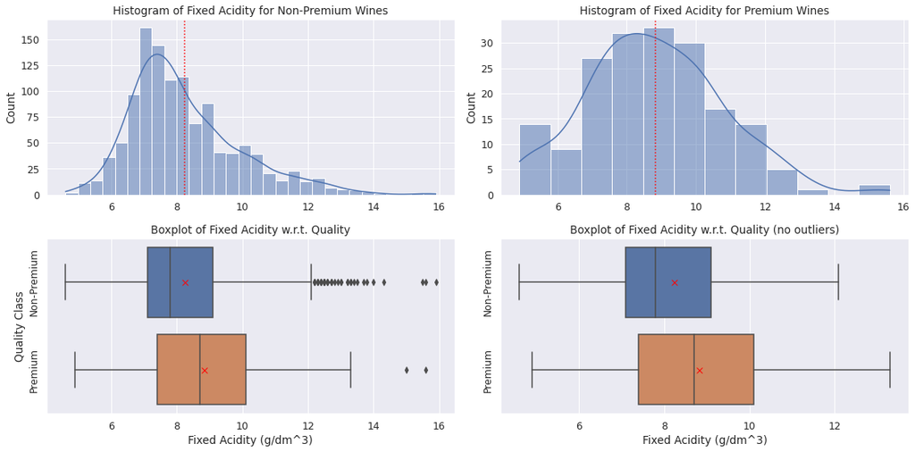

```python
# Feature to be plotted
plt_feature = 'fixed acidity'

plt.figure(figsize = (16, 8));
plt.subplot(221);
sns.histplot(data = df.loc[df['quality_cat'] == 'Non-Premium'], x = plt_feature, kde = True);
plt.axvline(df.loc[df['quality_cat'] == 'Non-Premium'][plt_feature].mean(), linestyle = ':', color = 'red');
plt.title('Histogram of Fixed Acidity for Non-Premium Wines');
plt.xlabel('');
plt.subplot(222);
sns.histplot(data = df.loc[df['quality_cat'] == 'Premium'], x = plt_feature, kde = True)
plt.axvline(df.loc[df['quality_cat'] == 'Premium'][plt_feature].mean(), linestyle = ':', color = 'red');
plt.title('Histogram of Fixed Acidity for Premium Wines');
plt.xlabel('');
plt.subplot(223);
sns.boxplot(data = df, x = plt_feature, y = 'quality_cat', showmeans = True,
            meanprops = {'marker': 'x', 'markerfacecolor': 'red', 'markeredgecolor': 'red', 'markersize': '7'});
plt.xlabel('Fixed Acidity (g/dm^3)');
plt.title('Boxplot of Fixed Acidity w.r.t. Quality');
plt.yticks(rotation = 90, va = 'center');
plt.ylabel('Quality Class');
plt.subplot(224);
sns.boxplot(data = df, x = plt_feature, y = 'quality_cat', showmeans = True, showfliers = False,
            meanprops = {'marker': 'x', 'markerfacecolor': 'red', 'markeredgecolor': 'red', 'markersize': '7'});
plt.xlabel('Fixed Acidity (g/dm^3)');
plt.title('Boxplot of Fixed Acidity w.r.t. Quality (no outliers)');
plt.ylabel('');
plt.yticks(rotation = 90, va = 'center');
plt.tight_layout();
```

**`Quality vs. Volatile Acidicity`**

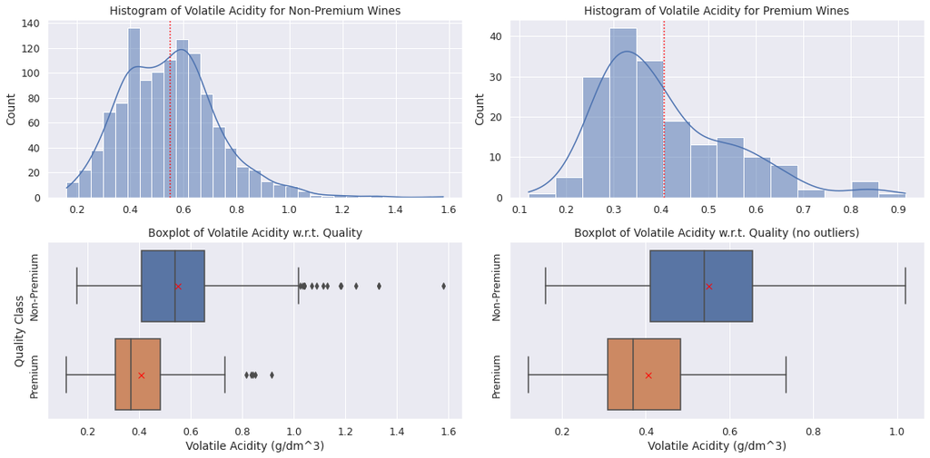

```python
# Feature to be plotted
plt_feature = 'volatile acidity'

plt.figure(figsize = (16, 8));
plt.subplot(221);
sns.histplot(data = df.loc[df['quality_cat'] == 'Non-Premium'], x = plt_feature, kde = True);
plt.axvline(df.loc[df['quality_cat'] == 'Non-Premium'][plt_feature].mean(), linestyle = ':', color = 'red');
plt.title('Histogram of Volatile Acidity for Non-Premium Wines');
plt.xlabel('');
plt.subplot(222);
sns.histplot(data = df.loc[df['quality_cat'] == 'Premium'], x = plt_feature, kde = True)
plt.axvline(df.loc[df['quality_cat'] == 'Premium'][plt_feature].mean(), linestyle = ':', color = 'red');
plt.title('Histogram of Volatile Acidity for Premium Wines');
plt.xlabel('');
plt.subplot(223);
sns.boxplot(data = df, x = plt_feature, y = 'quality_cat', showmeans = True,
            meanprops = {'marker': 'x', 'markerfacecolor': 'red', 'markeredgecolor': 'red', 'markersize': '7'});
plt.xlabel('Volatile Acidity (g/dm^3)');
plt.title('Boxplot of Volatile Acidity w.r.t. Quality');
plt.yticks(rotation = 90, va = 'center');
plt.ylabel('Quality Class');
plt.subplot(224);
sns.boxplot(data = df, x = plt_feature, y = 'quality_cat', showmeans = True, showfliers = False,
            meanprops = {'marker': 'x', 'markerfacecolor': 'red', 'markeredgecolor': 'red', 'markersize': '7'});
plt.xlabel('Volatile Acidity (g/dm^3)');
plt.title('Boxplot of Volatile Acidity w.r.t. Quality (no outliers)');
plt.ylabel('');
plt.yticks(rotation = 90, va = 'center');
plt.tight_layout();
```

**`Quality vs. Citric Acid`**

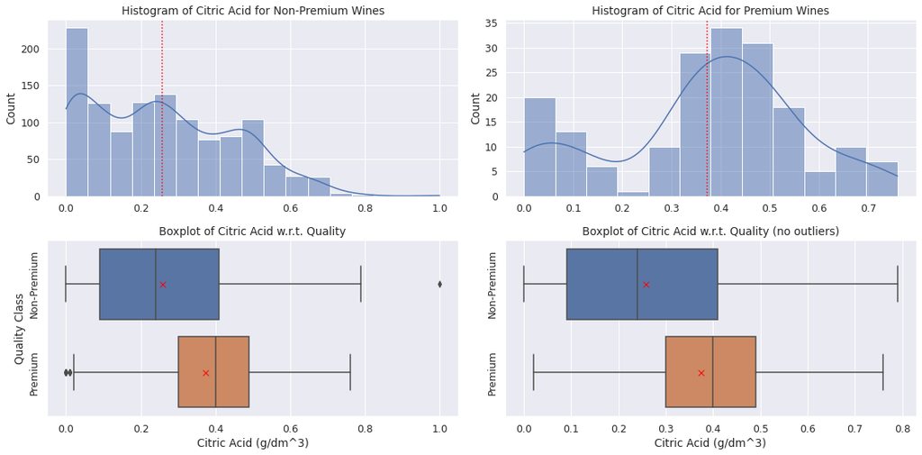

```python
# Feature to be plotted
plt_feature = 'citric acid'

plt.figure(figsize = (16, 8));
plt.subplot(221);
sns.histplot(data = df.loc[df['quality_cat'] == 'Non-Premium'], x = plt_feature, kde = True);
plt.axvline(df.loc[df['quality_cat'] == 'Non-Premium'][plt_feature].mean(), linestyle = ':', color = 'red');
plt.title('Histogram of Citric Acid for Non-Premium Wines');
plt.xlabel('');
plt.subplot(222);
sns.histplot(data = df.loc[df['quality_cat'] == 'Premium'], x = plt_feature, kde = True)
plt.axvline(df.loc[df['quality_cat'] == 'Premium'][plt_feature].mean(), linestyle = ':', color = 'red');
plt.title('Histogram of Citric Acid for Premium Wines');
plt.xlabel('');
plt.subplot(223);
sns.boxplot(data = df, x = plt_feature, y = 'quality_cat', showmeans = True,
            meanprops = {'marker': 'x', 'markerfacecolor': 'red', 'markeredgecolor': 'red', 'markersize': '7'});
plt.xlabel('Citric Acid (g/dm^3)');
plt.title('Boxplot of Citric Acid w.r.t. Quality');
plt.yticks(rotation = 90, va = 'center');
plt.ylabel('Quality Class');
plt.subplot(224);
sns.boxplot(data = df, x = plt_feature, y = 'quality_cat', showmeans = True, showfliers = False,
            meanprops = {'marker': 'x', 'markerfacecolor': 'red', 'markeredgecolor': 'red', 'markersize': '7'});
plt.xlabel('Citric Acid (g/dm^3)');
plt.title('Boxplot of Citric Acid w.r.t. Quality (no outliers)');
plt.ylabel('');
plt.yticks(rotation = 90, va = 'center');
plt.tight_layout();
```

**`Quality vs. Residual Sugar`**

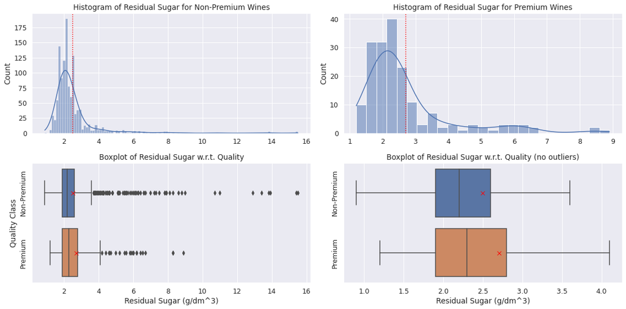

```python
# Feature to be plotted
plt_feature = 'residual sugar'

plt.figure(figsize = (16, 8));
plt.subplot(221);
sns.histplot(data = df.loc[df['quality_cat'] == 'Non-Premium'], x = plt_feature, kde = True);
plt.axvline(df.loc[df['quality_cat'] == 'Non-Premium'][plt_feature].mean(), linestyle = ':', color = 'red');
plt.title('Histogram of Residual Sugar for Non-Premium Wines');
plt.xlabel('');
plt.subplot(222);
sns.histplot(data = df.loc[df['quality_cat'] == 'Premium'], x = plt_feature, kde = True)
plt.axvline(df.loc[df['quality_cat'] == 'Premium'][plt_feature].mean(), linestyle = ':', color = 'red');
plt.title('Histogram of Residual Sugar for Premium Wines');
plt.xlabel('');
plt.subplot(223);
sns.boxplot(data = df, x = plt_feature, y = 'quality_cat', showmeans = True,
            meanprops = {'marker': 'x', 'markerfacecolor': 'red', 'markeredgecolor': 'red', 'markersize': '7'});
plt.xlabel('Residual Sugar (g/dm^3)');
plt.title('Boxplot of Residual Sugar w.r.t. Quality');
plt.yticks(rotation = 90, va = 'center');
plt.ylabel('Quality Class');
plt.subplot(224);
sns.boxplot(data = df, x = plt_feature, y = 'quality_cat', showmeans = True, showfliers = False,
            meanprops = {'marker': 'x', 'markerfacecolor': 'red', 'markeredgecolor': 'red', 'markersize': '7'});
plt.xlabel('Residual Sugar (g/dm^3)');
plt.title('Boxplot of Residual Sugar w.r.t. Quality (no outliers)');
plt.ylabel('');
plt.yticks(rotation = 90, va = 'center');
plt.tight_layout();
```

**`Quality vs. Chlorides`**

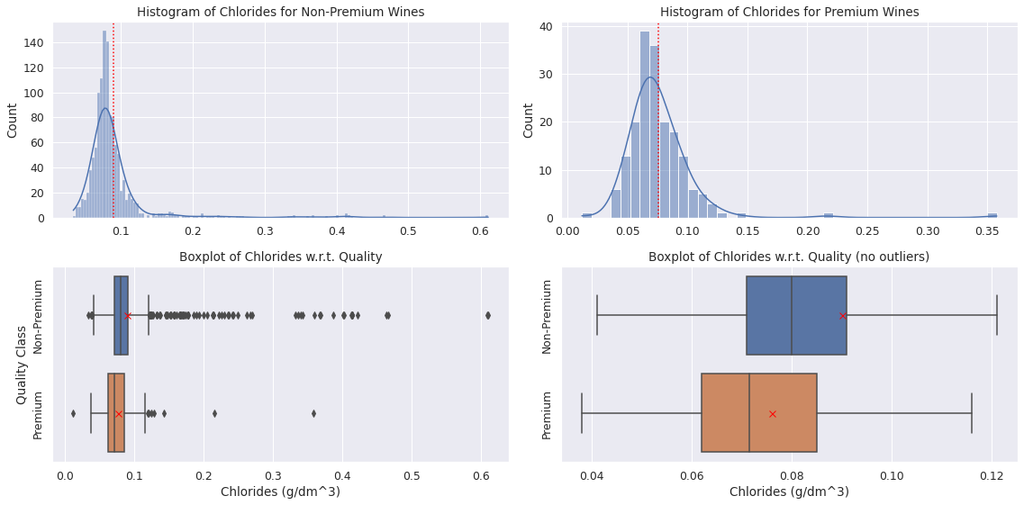

```python
# Feature to be plotted
plt_feature = 'chlorides'

plt.figure(figsize = (16, 8));
plt.subplot(221);
sns.histplot(data = df.loc[df['quality_cat'] == 'Non-Premium'], x = plt_feature, kde = True);
plt.axvline(df.loc[df['quality_cat'] == 'Non-Premium'][plt_feature].mean(), linestyle = ':', color = 'red');
plt.title('Histogram of Chlorides for Non-Premium Wines');
plt.xlabel('');
plt.subplot(222);
sns.histplot(data = df.loc[df['quality_cat'] == 'Premium'], x = plt_feature, kde = True)
plt.axvline(df.loc[df['quality_cat'] == 'Premium'][plt_feature].mean(), linestyle = ':', color = 'red');
plt.title('Histogram of Chlorides for Premium Wines');
plt.xlabel('');
plt.subplot(223);
sns.boxplot(data = df, x = plt_feature, y = 'quality_cat', showmeans = True,
            meanprops = {'marker': 'x', 'markerfacecolor': 'red', 'markeredgecolor': 'red', 'markersize': '7'});
plt.xlabel('Chlorides (g/dm^3)');
plt.title('Boxplot of Chlorides w.r.t. Quality');
plt.yticks(rotation = 90, va = 'center');
plt.ylabel('Quality Class');
plt.subplot(224);
sns.boxplot(data = df, x = plt_feature, y = 'quality_cat', showmeans = True, showfliers = False,
            meanprops = {'marker': 'x', 'markerfacecolor': 'red', 'markeredgecolor': 'red', 'markersize': '7'});
plt.xlabel('Chlorides (g/dm^3)');
plt.title('Boxplot of Chlorides w.r.t. Quality (no outliers)');
plt.ylabel('');
plt.yticks(rotation = 90, va = 'center');
plt.tight_layout();
```

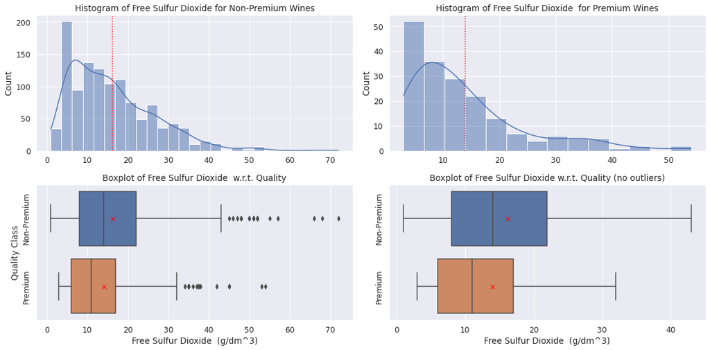

```python
# Feature to be plotted
plt_feature = 'free sulfur dioxide'

plt.figure(figsize = (16, 8));
plt.subplot(221);
sns.histplot(data = df.loc[df['quality_cat'] == 'Non-Premium'], x = plt_feature, kde = True);
plt.axvline(df.loc[df['quality_cat'] == 'Non-Premium'][plt_feature].mean(), linestyle = ':', color = 'red');
plt.title('Histogram of Free Sulfur Dioxide for Non-Premium Wines');
plt.xlabel('');
plt.subplot(222);
sns.histplot(data = df.loc[df['quality_cat'] == 'Premium'], x = plt_feature, kde = True)
plt.axvline(df.loc[df['quality_cat'] == 'Premium'][plt_feature].mean(), linestyle = ':', color = 'red');
plt.title('Histogram of Free Sulfur Dioxide  for Premium Wines');
plt.xlabel('');
plt.subplot(223);
sns.boxplot(data = df, x = plt_feature, y = 'quality_cat', showmeans = True,
            meanprops = {'marker': 'x', 'markerfacecolor': 'red', 'markeredgecolor': 'red', 'markersize': '7'});
plt.xlabel('Free Sulfur Dioxide  (g/dm^3)');
plt.title('Boxplot of Free Sulfur Dioxide  w.r.t. Quality');
plt.yticks(rotation = 90, va = 'center');
plt.ylabel('Quality Class');
plt.subplot(224);
sns.boxplot(data = df, x = plt_feature, y = 'quality_cat', showmeans = True, showfliers = False,
            meanprops = {'marker': 'x', 'markerfacecolor': 'red', 'markeredgecolor': 'red', 'markersize': '7'});
plt.xlabel('Free Sulfur Dioxide  (g/dm^3)');
plt.title('Boxplot of Free Sulfur Dioxide w.r.t. Quality (no outliers)');
plt.ylabel('');
plt.yticks(rotation = 90, va = 'center');
plt.tight_layout();
```

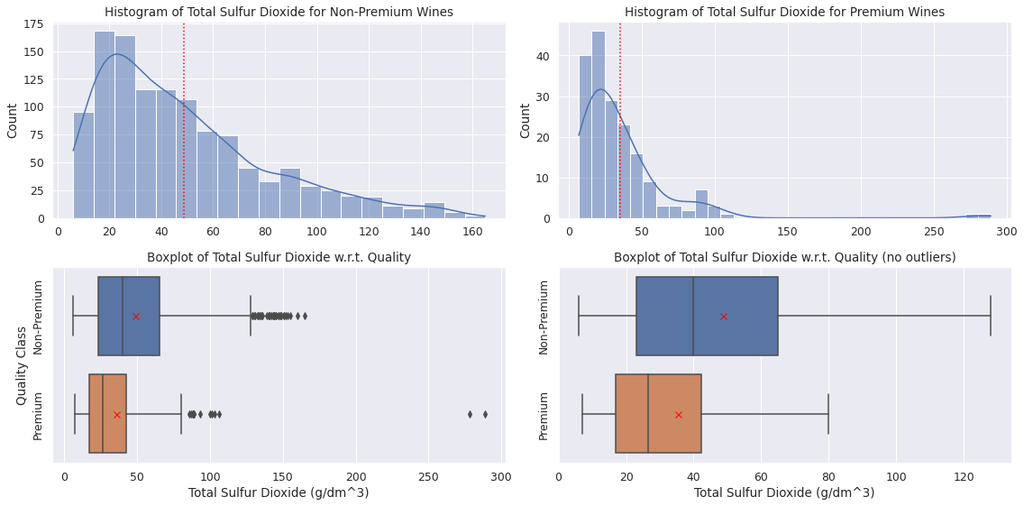

```python
# Feature to be plotted
plt_feature = 'total sulfur dioxide'

plt.figure(figsize = (16, 8));
plt.subplot(221);
sns.histplot(data = df.loc[df['quality_cat'] == 'Non-Premium'], x = plt_feature, kde = True);
plt.axvline(df.loc[df['quality_cat'] == 'Non-Premium'][plt_feature].mean(), linestyle = ':', color = 'red');
plt.title('Histogram of Total Sulfur Dioxide for Non-Premium Wines');
plt.xlabel('');
plt.subplot(222);
sns.histplot(data = df.loc[df['quality_cat'] == 'Premium'], x = plt_feature, kde = True)
plt.axvline(df.loc[df['quality_cat'] == 'Premium'][plt_feature].mean(), linestyle = ':', color = 'red');
plt.title('Histogram of Total Sulfur Dioxide for Premium Wines');
plt.xlabel('');
plt.subplot(223);
sns.boxplot(data = df, x = plt_feature, y = 'quality_cat', showmeans = True,
            meanprops = {'marker': 'x', 'markerfacecolor': 'red', 'markeredgecolor': 'red', 'markersize': '7'});
plt.xlabel('Total Sulfur Dioxide (g/dm^3)');
plt.title('Boxplot of Total Sulfur Dioxide w.r.t. Quality');
plt.yticks(rotation = 90, va = 'center');
plt.ylabel('Quality Class');
plt.subplot(224);
sns.boxplot(data = df, x = plt_feature, y = 'quality_cat', showmeans = True, showfliers = False,
            meanprops = {'marker': 'x', 'markerfacecolor': 'red', 'markeredgecolor': 'red', 'markersize': '7'});
plt.xlabel('Total Sulfur Dioxide (g/dm^3)');
plt.title('Boxplot of Total Sulfur Dioxide w.r.t. Quality (no outliers)');
plt.ylabel('');
plt.yticks(rotation = 90, va = 'center');
plt.tight_layout();
```

**`Quality vs. Density`**

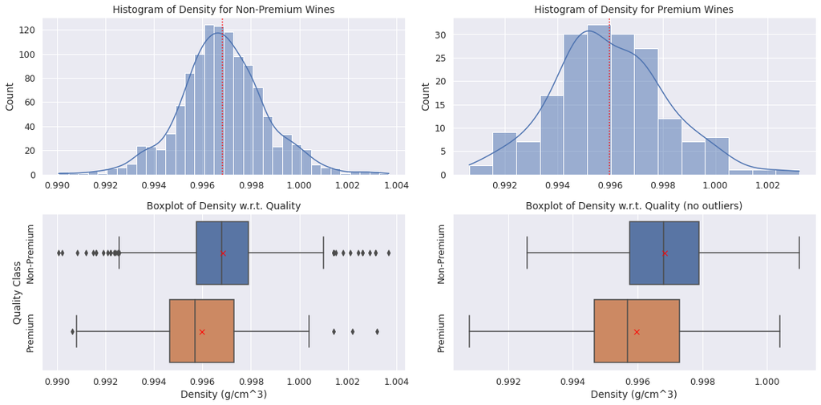

```python
# Feature to be plotted
plt_feature = 'density'

plt.figure(figsize = (16, 8));
plt.subplot(221);
sns.histplot(data = df.loc[df['quality_cat'] == 'Non-Premium'], x = plt_feature, kde = True);
plt.axvline(df.loc[df['quality_cat'] == 'Non-Premium'][plt_feature].mean(), linestyle = ':', color = 'red');
plt.title('Histogram of Density for Non-Premium Wines');
plt.xlabel('');
plt.subplot(222);
sns.histplot(data = df.loc[df['quality_cat'] == 'Premium'], x = plt_feature, kde = True)
plt.axvline(df.loc[df['quality_cat'] == 'Premium'][plt_feature].mean(), linestyle = ':', color = 'red');
plt.title('Histogram of Density for Premium Wines');
plt.xlabel('');
plt.subplot(223);
sns.boxplot(data = df, x = plt_feature, y = 'quality_cat', showmeans = True,
            meanprops = {'marker': 'x', 'markerfacecolor': 'red', 'markeredgecolor': 'red', 'markersize': '7'});
plt.xlabel('Density (g/cm^3)');
plt.title('Boxplot of Density w.r.t. Quality');
plt.yticks(rotation = 90, va = 'center');
plt.ylabel('Quality Class');
plt.subplot(224);
sns.boxplot(data = df, x = plt_feature, y = 'quality_cat', showmeans = True, showfliers = False,
            meanprops = {'marker': 'x', 'markerfacecolor': 'red', 'markeredgecolor': 'red', 'markersize': '7'});
plt.xlabel('Density (g/cm^3)');
plt.title('Boxplot of Density w.r.t. Quality (no outliers)');
plt.ylabel('');
plt.yticks(rotation = 90, va = 'center');
plt.tight_layout();
```

**`Quality vs. pH`**

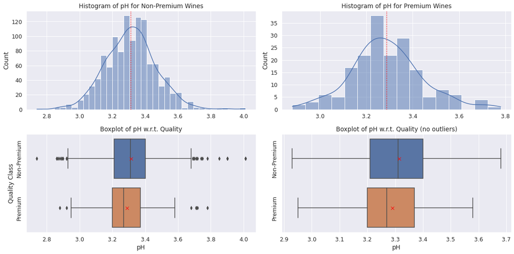

```python
# Feature to be plotted
plt_feature = 'pH'

plt.figure(figsize = (16, 8));
plt.subplot(221);
sns.histplot(data = df.loc[df['quality_cat'] == 'Non-Premium'], x = plt_feature, kde = True);
plt.axvline(df.loc[df['quality_cat'] == 'Non-Premium'][plt_feature].mean(), linestyle = ':', color = 'red');
plt.title('Histogram of pH for Non-Premium Wines');
plt.xlabel('');
plt.subplot(222);
sns.histplot(data = df.loc[df['quality_cat'] == 'Premium'], x = plt_feature, kde = True)
plt.axvline(df.loc[df['quality_cat'] == 'Premium'][plt_feature].mean(), linestyle = ':', color = 'red');
plt.title('Histogram of pH for Premium Wines');
plt.xlabel('');
plt.subplot(223);
sns.boxplot(data = df, x = plt_feature, y = 'quality_cat', showmeans = True,
            meanprops = {'marker': 'x', 'markerfacecolor': 'red', 'markeredgecolor': 'red', 'markersize': '7'});
plt.xlabel('pH');
plt.title('Boxplot of pH w.r.t. Quality');
plt.yticks(rotation = 90, va = 'center');
plt.ylabel('Quality Class');
plt.subplot(224);
sns.boxplot(data = df, x = plt_feature, y = 'quality_cat', showmeans = True, showfliers = False,
            meanprops = {'marker': 'x', 'markerfacecolor': 'red', 'markeredgecolor': 'red', 'markersize': '7'});
plt.xlabel('pH');
plt.title('Boxplot of pH w.r.t. Quality (no outliers)');
plt.ylabel('');
plt.yticks(rotation = 90, va = 'center');
plt.tight_layout();
```

**`Quality vs. Sulphates`**

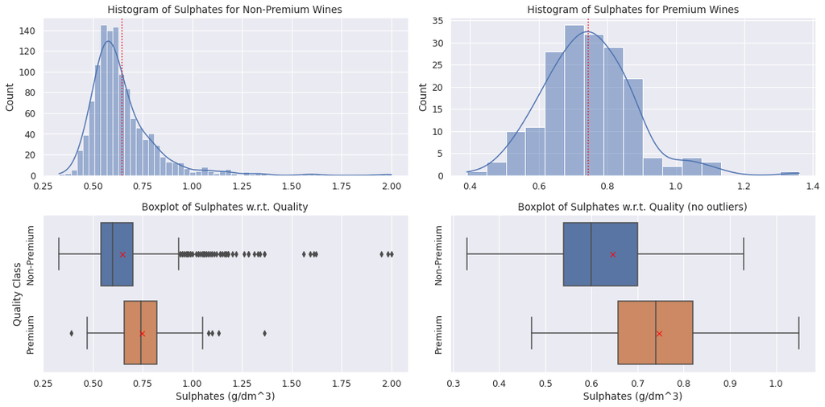

```python
# Feature to be plotted
plt_feature = 'sulphates'

plt.figure(figsize = (16, 8));
plt.subplot(221);
sns.histplot(data = df.loc[df['quality_cat'] == 'Non-Premium'], x = plt_feature, kde = True);
plt.axvline(df.loc[df['quality_cat'] == 'Non-Premium'][plt_feature].mean(), linestyle = ':', color = 'red');
plt.title('Histogram of Sulphates for Non-Premium Wines');
plt.xlabel('');
plt.subplot(222);
sns.histplot(data = df.loc[df['quality_cat'] == 'Premium'], x = plt_feature, kde = True)
plt.axvline(df.loc[df['quality_cat'] == 'Premium'][plt_feature].mean(), linestyle = ':', color = 'red');
plt.title('Histogram of Sulphates for Premium Wines');
plt.xlabel('');
plt.subplot(223);
sns.boxplot(data = df, x = plt_feature, y = 'quality_cat', showmeans = True,
            meanprops = {'marker': 'x', 'markerfacecolor': 'red', 'markeredgecolor': 'red', 'markersize': '7'});
plt.xlabel('Sulphates (g/dm^3)');
plt.title('Boxplot of Sulphates w.r.t. Quality');
plt.yticks(rotation = 90, va = 'center');
plt.ylabel('Quality Class');
plt.subplot(224);
sns.boxplot(data = df, x = plt_feature, y = 'quality_cat', showmeans = True, showfliers = False,
            meanprops = {'marker': 'x', 'markerfacecolor': 'red', 'markeredgecolor': 'red', 'markersize': '7'});
plt.xlabel('Sulphates (g/dm^3)');
plt.title('Boxplot of Sulphates w.r.t. Quality (no outliers)');
plt.ylabel('');
plt.yticks(rotation = 90, va = 'center');
plt.tight_layout();
```

**`Quality vs. Alcohol`**

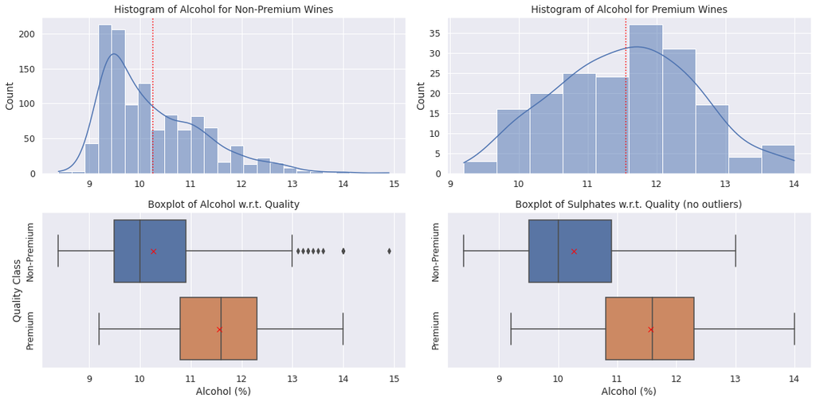

```python
# Feature to be plotted
plt_feature = 'alcohol'

plt.figure(figsize = (16, 8));
plt.subplot(221);
sns.histplot(data = df.loc[df['quality_cat'] == 'Non-Premium'], x = plt_feature, kde = True);
plt.axvline(df.loc[df['quality_cat'] == 'Non-Premium'][plt_feature].mean(), linestyle = ':', color = 'red');
plt.title('Histogram of Alcohol for Non-Premium Wines');
plt.xlabel('');
plt.subplot(222);
sns.histplot(data = df.loc[df['quality_cat'] == 'Premium'], x = plt_feature, kde = True)
plt.axvline(df.loc[df['quality_cat'] == 'Premium'][plt_feature].mean(), linestyle = ':', color = 'red');
plt.title('Histogram of Alcohol for Premium Wines');
plt.xlabel('');
plt.subplot(223);
sns.boxplot(data = df, x = plt_feature, y = 'quality_cat', showmeans = True,
            meanprops = {'marker': 'x', 'markerfacecolor': 'red', 'markeredgecolor': 'red', 'markersize': '7'});
plt.xlabel('Alcohol (%)');
plt.title('Boxplot of Alcohol w.r.t. Quality');
plt.yticks(rotation = 90, va = 'center');
plt.ylabel('Quality Class');
plt.subplot(224);
sns.boxplot(data = df, x = plt_feature, y = 'quality_cat', showmeans = True, showfliers = False,
            meanprops = {'marker': 'x', 'markerfacecolor': 'red', 'markeredgecolor': 'red', 'markersize': '7'});
plt.xlabel('Alcohol (%)');
plt.title('Boxplot of Sulphates w.r.t. Quality (no outliers)');
plt.ylabel('');
plt.yticks(rotation = 90, va = 'center');
plt.tight_layout();
```

## ML-based Classification Model Building

- Here, we use two parallel (*Bagging* and *Random Forest*) and two sequential (*Adaptive Boosting* and *Gradient Boosting*) ensemble techniques to construct ML-based models capable of separating premium ones from the others. All these models will also be compared against a (pre-pruned) decision tree and a stacking classifier built using all of them.
- Due to its massive computational costs, XGBoost will be avoided, except as the meta-classifier of the stacking model.
- Here, we select *F1-score* to evaluate the performance of all models, since we do not want to miss any premium wine, and also don't want to mislabel non-premium ones as premium. If the former isn't satisfied, we would lose money as a premium wine would be sold at a much lower price, and if the latter isn't met, the customers will be really upset with our low-quality, overpriced wine.

```python
## Auxiliray function for reporting the performance metrics of a model

def model_eval(model, X_train, X_test, y_train, y_test):
    '''This function calculates all relevant performance metrics of a classification
    model on training and testing data, and returns them in the form of a dataframe.'''

    # Reconstructing the training set
    y_recon = model.predict(X_train)
    # Making predictions for training set
    y_pred  = model.predict(X_test)

    # Building a dataframe containing all evaluation metrics
    model_perform = pd.DataFrame(index = ['Train', 'Test'], columns = ['Accuracy', 'Recall',
                                                          'Precision', 'F1', 'Specificity'])
    # Assessing performance on training data
    model_perform.iloc[0, :] = [accuracy_score(y_train, y_recon), recall_score(y_train, y_recon),
                                precision_score(y_train, y_recon), f1_score(y_train, y_recon),
                                recall_score(y_train, y_recon, pos_label = 0)]
    # Assessing performance on testing data
    model_perform.iloc[1, :] = [accuracy_score(y_test, y_pred), recall_score(y_test, y_pred),
                                precision_score(y_test, y_pred), f1_score(y_test, y_pred),
                                recall_score(y_test, y_pred, pos_label = 0)]
    return model_perform
```

```python
## Auxiliray function for plotting the confusion matrices of a model as a heatmap

def make_confusion_matrix(y_truth, y_pred):
    '''This function generates the confusion matrix and returns it as a heatmap.'''

    # Calculating the confusion matrix
    cm = confusion_matrix(y_truth, y_pred)
    # Converting the confusion matrix into a dataframe
    cm_df = pd.DataFrame(cm, index = ['Truth - Non-Prem.', 'Truth - Prem.'],
                         columns = ['Prediction - Non-Prem.', 'Prediction - Prem.'])
    # Generating the labels of the heatmap
    labels = []
    for i in range(len(cm.flatten())):
        labels.append(str(cm.flatten()[i]) + '\n(' + str(np.round(cm.flatten()[i]/cm.flatten().sum()*100, 2)) + '%)')
    labels = np.asarray(labels).reshape(2, 2)
    # Plotting the heatmap
    sns.heatmap(cm_df, fmt = '', annot = labels, cbar = False, cmap = 'seismic',
                vmin = -len(y_truth), vmax = len(y_truth))
    plt.yticks(rotation = 90, va = 'center');
    plt.xlabel('Prediction');
    plt.ylabel('Truth');
```

### Data Preparation

```python
# Dropping unnecessary columns for modeling
df_model = df.drop(columns = ['quality', 'quality_cat'], axis = 1)
df_model.rename(columns = {'quality_num': 'quality'}, inplace = True)

df_model.head(5)
```

|  | fixed acidity | volatile acidity | citric acid | residual sugar | chlorides | free sulfur dioxide | total sulfur dioxide | density | pH | sulphates | alcohol | quality |
| --- | --- | --- | --- | --- | --- | --- | --- | --- | --- | --- | --- | --- |
| 0 | 7.400 | 0.700 | 0.000 | 1.900 | 0.076 | 11.000 | 34.000 | 0.998 | 3.510 | 0.560 | 9.400 | 0 |
| 1 | 7.800 | 0.880 | 0.000 | 2.600 | 0.098 | 25.000 | 67.000 | 0.997 | 3.200 | 0.680 | 9.800 | 0 |
| 2 | 7.800 | 0.760 | 0.040 | 2.300 | 0.092 | 15.000 | 54.000 | 0.997 | 3.260 | 0.650 | 9.800 | 0 |
| 3 | 11.200 | 0.280 | 0.560 | 1.900 | 0.075 | 17.000 | 60.000 | 0.998 | 3.160 | 0.580 | 9.800 | 0 |
| 5 | 7.400 | 0.660 | 0.000 | 1.800 | 0.075 | 13.000 | 40.000 | 0.998 | 3.510 | 0.560 | 9.400 | 0 |

```python
# Separating predictors and target
y = df_model['quality']
X = df_model.drop(columns = 'quality', axis = 1)

# Constructing training and testing sets
X_train, X_test, y_train, y_test = train_test_split(X, y, random_state = 1, test_size = 0.3, stratify = y)
```

```python
print('Fraction of target classes in training set:\n' + str(y_train.value_counts(1)), end = '\n'*2)
print('Fraction of target classes in testing set:\n' + str(y_test.value_counts(1)))
```

```
Fraction of target classes in training set:
0   0.864
1   0.136
Name: quality, dtype: float64

Fraction of target classes in testing set:
0   0.865
1   0.135
Name: quality, dtype: float64
```

### Decision Tree

```python
# Building the full Tree
dtr0 = DecisionTreeClassifier(random_state = 1)
dtr0 = dtr0.fit(X_train, y_train)
```

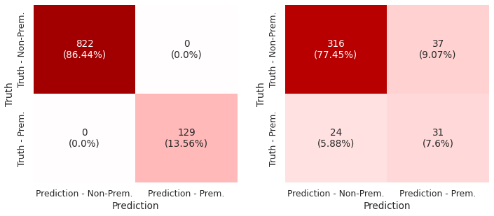

```python
# Confusion matrix of full tree

# Reconstructing the training data
y_recon = dtr0.predict(X_train)
# Forecasting the testing data
y_pred = dtr0.predict(X_test)

# Plotting the confusion matrices for training and testing  data
plt.figure(figsize = (10, 4.5));
plt.subplot(121);
make_confusion_matrix(y_train, y_recon);
plt.subplot(122);
make_confusion_matrix(y_test, y_pred);
plt.tight_layout(w_pad = 2);
```

```python
# Model performance of full tree
dtr0_perform = model_eval(dtr0, X_train, X_test, y_train, y_test)
dtr0_perform
```

|  | Accuracy | Recall | Precision | F1 | Specificity |
| --- | --- | --- | --- | --- | --- |
| Train | 1.000 | 1.000 | 1.000 | 1.000 | 1.000 |
| Test | 0.850 | 0.564 | 0.456 | 0.504 | 0.895 |

```python
# Tuning the decision tree
base_estimator = DecisionTreeClassifier(random_state = 1)

# Setting the range of hyperparameters
hyperparams = {'class_weight': ['balanced', None], 'splitter': ['random', 'best'],
               'max_depth': np.arange(3, 12), 'max_leaf_nodes': [5, 10, 20, 30, 40, 50],
               'min_samples_split': [4, 6, 8, 10], 'min_impurity_decrease': [1e-5, 1e-4, 1e-3, 0.01]}

# Setting the performance criterion
acc_criterion = make_scorer(f1_score)

# Doing an exhaustive search over the full range of hyperparameters
all_models = GridSearchCV(base_estimator, param_grid = hyperparams, scoring = acc_criterion, cv = 5)
all_models = all_models.fit(X_train, y_train)

# Selecting the best model
dtr_tuned = all_models.best_estimator_
dtr_tuned = dtr_tuned.fit(X_train, y_train)
dtr_tuned
```

```
DecisionTreeClassifier(class_weight='balanced', max_depth=4, max_leaf_nodes=10,
                       min_impurity_decrease=0.01, min_samples_split=4,
                       random_state=1)
```

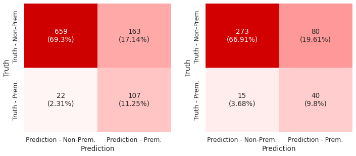

```python
# Confusion matrix of tuned model

# Reconstructing the training data
y_recon = dtr_tuned.predict(X_train)
# Forecasting the testing data
y_pred = dtr_tuned.predict(X_test)

# Plotting the confusion matrices for training and testing  data
plt.figure(figsize = (10, 4.5));
plt.subplot(121);
make_confusion_matrix(y_train, y_recon);
plt.subplot(122);
make_confusion_matrix(y_test, y_pred);
plt.tight_layout(w_pad = 2);
```

```python
# Model performance of tuned tree
dtr_tuned_perform = model_eval(dtr_tuned, X_train, X_test, y_train, y_test)
dtr_tuned_perform
```

|  | Accuracy | Recall | Precision | F1 | Specificity |
| --- | --- | --- | --- | --- | --- |
| Train | 0.805 | 0.829 | 0.396 | 0.536 | 0.802 |
| Test | 0.767 | 0.727 | 0.333 | 0.457 | 0.773 |

### Bagging Classifier

```python
# Building the initial model
bgc0 = BaggingClassifier(random_state = 1)
bgc0 = bgc0.fit(X_train, y_train)
```

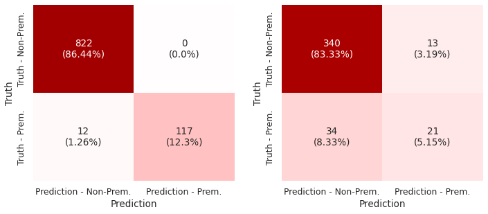

```python
# Confusion matrix of initial model

# Reconstructing the training data
y_recon = bgc0.predict(X_train)
# Forecasting the testing data
y_pred = bgc0.predict(X_test)

# Plotting the confusion matrices for training and testing  data
plt.figure(figsize = (10, 4.5));
plt.subplot(121);
make_confusion_matrix(y_train, y_recon);
plt.subplot(122);
make_confusion_matrix(y_test, y_pred);
plt.tight_layout(w_pad = 2);
```

```python
# Model performance of initial model
bgc0_perform = model_eval(bgc0, X_train, X_test, y_train, y_test)
bgc0_perform
```

|  | Accuracy | Recall | Precision | F1 | Specificity |
| --- | --- | --- | --- | --- | --- |
| Train | 0.987 | 0.907 | 1.000 | 0.951 | 1.000 |
| Test | 0.885 | 0.382 | 0.618 | 0.472 | 0.963 |

```python
# Tuning the decision tree
base_estimator = BaggingClassifier(random_state = 1)

# Setting the range of hyperparameters
hyperparams = {'base_estimator': [DecisionTreeClassifier(random_state = 1),
                                  DecisionTreeClassifier(random_state = 1, class_weight = 'balanced')],
               'n_estimators': [10, 30, 50, 100, 200], 'max_samples': [0.5, 0.6, 0.8, 1],
               'max_features': [0.5, 0.6, 0.8, 1]}

# Setting the performance criterion
acc_criterion = make_scorer(f1_score)

# Doing an exhaustive search over the full range of hyperparameters
all_models = GridSearchCV(base_estimator, param_grid = hyperparams, scoring = acc_criterion, cv = 5)
all_models = all_models.fit(X_train, y_train)

# Selecting the best model
bgc_tuned = all_models.best_estimator_
bgc_tuned = bgc_tuned.fit(X_train, y_train)
bgc_tuned
```

```
BaggingClassifier(base_estimator=DecisionTreeClassifier(random_state=1),
                  max_features=0.8, max_samples=0.8, n_estimators=50,
                  random_state=1)
```

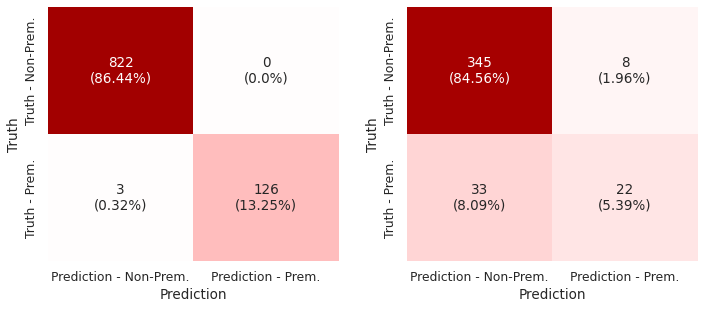

```python
# Confusion matrix of tuned model

# Reconstructing the training data
y_recon = bgc_tuned.predict(X_train)
# Forecasting the testing data
y_pred = bgc_tuned.predict(X_test)

# Plotting the confusion matrices for training and testing  data
plt.figure(figsize = (10, 4.5));
plt.subplot(121);
make_confusion_matrix(y_train, y_recon);
plt.subplot(122);
make_confusion_matrix(y_test, y_pred);
plt.tight_layout(w_pad = 2);
```

```python
# Model performance of tuned model
bgc_tuned_perform = model_eval(bgc_tuned, X_train, X_test, y_train, y_test)
bgc_tuned_perform
```

|  | Accuracy | Recall | Precision | F1 | Specificity |
| --- | --- | --- | --- | --- | --- |
| Train | 0.997 | 0.977 | 1.000 | 0.988 | 1.000 |
| Test | 0.900 | 0.400 | 0.733 | 0.518 | 0.977 |

### Random Forest

```python
# Building the initial model
rfc0 = BaggingClassifier(random_state = 1)
rfc0 = rfc0.fit(X_train, y_train)
```

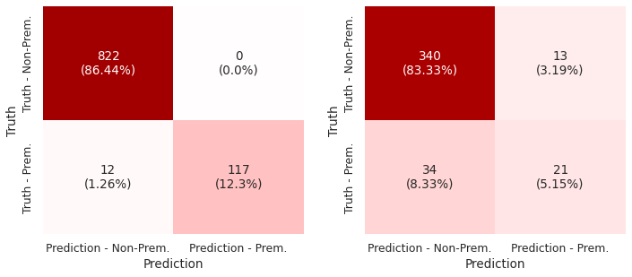

```python
# Confusion matrix of initial model

# Reconstructing the training data
y_recon = rfc0.predict(X_train)
# Forecasting the testing data
y_pred = rfc0.predict(X_test)

# Plotting the confusion matrices for training and testing  data
plt.figure(figsize = (10, 4.5));
plt.subplot(121);
make_confusion_matrix(y_train, y_recon);
plt.subplot(122);
make_confusion_matrix(y_test, y_pred);
plt.tight_layout(w_pad = 2);
```

```python
# Model performance of tuned model
rfc0_perform = model_eval(rfc0, X_train, X_test, y_train, y_test)
rfc0_perform
```

|  | Accuracy | Recall | Precision | F1 | Specificity |
| --- | --- | --- | --- | --- | --- |
| Train | 0.987 | 0.907 | 1.000 | 0.951 | 1.000 |
| Test | 0.885 | 0.382 | 0.618 | 0.472 | 0.963 |

```python
# Tuning the decision tree
base_estimator = RandomForestClassifier(class_weight = {0: 0.136, 1: 0.864}, random_state = 1)

# Setting the range of hyperparameters
hyperparams = {'max_depth': np.arange(3, 8), 'min_impurity_decrease': [1e-4, 1e-3, 0.01, 0.05],
               'n_estimators': [10, 30, 50, 100, 200], 'max_samples': [0.5, 0.6, 0.8, 1],
               'max_features': [0.5, 0.6, 0.8, 1]}

# Setting the performance criterion
acc_criterion = make_scorer(f1_score)

# Doing an exhaustive search over the full range of hyperparameters
all_models = GridSearchCV(base_estimator, param_grid = hyperparams, scoring = acc_criterion, cv = 5)
all_models = all_models.fit(X_train, y_train)

# Selecting the best model
rfc_tuned = all_models.best_estimator_
rfc_tuned = rfc_tuned.fit(X_train, y_train)
rfc_tuned
```

```
RandomForestClassifier(class_weight={0: 0.136, 1: 0.864}, max_depth=4,
                       max_features=1, max_samples=0.5,
                       min_impurity_decrease=0.001, n_estimators=200,
                       random_state=1)
```

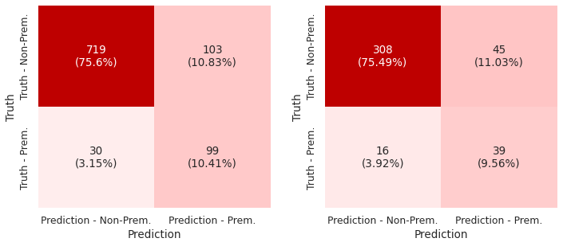

```python
# Confusion matrix of tuned model

# Reconstructing the training data
y_recon = rfc_tuned.predict(X_train)
# Forecasting the testing data
y_pred = rfc_tuned.predict(X_test)

# Plotting the confusion matrices for training and testing  data
plt.figure(figsize = (10, 4.5));
plt.subplot(121);
make_confusion_matrix(y_train, y_recon);
plt.subplot(122);
make_confusion_matrix(y_test, y_pred);
plt.tight_layout(w_pad = 2);
```

```python
# Model performance of tuned model
rfc_tuned_perform = model_eval(rfc_tuned, X_train, X_test, y_train, y_test)
rfc_tuned_perform
```

|  | Accuracy | Recall | Precision | F1 | Specificity |
| --- | --- | --- | --- | --- | --- |
| Train | 0.860 | 0.767 | 0.490 | 0.598 | 0.875 |
| Test | 0.850 | 0.709 | 0.464 | 0.561 | 0.873 |